# 白葡萄酒质量数据集分析 by xieli

```r
# 查看当前路径
getwd()
```

```
## [1] "/Users/lixie/MyProjects/UdaCourse/advance-P3/proj"
```

# Univariate Plots Section

[output not shown]

[output cut: 14682 more lines]

# Univariate Analysis

### What is the structure of your dataset?

```r
names(df)
```

```
##  [1] "X"                    "fixed.acidity"        "volatile.acidity"
##  [4] "citric.acid"          "residual.sugar"       "chlorides"
##  [7] "free.sulfur.dioxide"  "total.sulfur.dioxide" "density"
## [10] "pH"                   "sulphates"            "alcohol"
## [13] "quality"
```

#### 该数据集包括4898条记录

#### 查看数据集，并对每个特征进行理解，该数据集总共包括12个变量：

1. fixed.acidity 非挥发性酸
2. volatile.acidity 挥发性酸
3. citric.acid 柠檬酸
4. residual.sugar 剩余糖分
5. chlorides 氯化物
6. free.sulfur.dioxide 游离二氧化硫量
7. total.sulfur.dioxide 总二氧化硫量
8. density 密度
9. pH 酸碱度
10. sulphates 硫酸盐
11. alcohol 酒精度数
12. quality 质量评分

```r
# 数据是否有缺失值
sum(is.na(df))
```

```
## [1] 0
```

```r
# 是否有重复的值
sum(duplicated(df))
```

```
## [1] 0
```

```r
summary(df)
```

```
##        X        fixed.acidity    volatile.acidity  citric.acid
##  Min.   :   1   Min.   : 3.800   Min.   :0.0800   Min.   :0.0000
##  1st Qu.:1225   1st Qu.: 6.300   1st Qu.:0.2100   1st Qu.:0.2700
##  Median :2450   Median : 6.800   Median :0.2600   Median :0.3200
##  Mean   :2450   Mean   : 6.855   Mean   :0.2782   Mean   :0.3342
##  3rd Qu.:3674   3rd Qu.: 7.300   3rd Qu.:0.3200   3rd Qu.:0.3900
##  Max.   :4898   Max.   :14.200   Max.   :1.1000   Max.   :1.6600
##  residual.sugar     chlorides       free.sulfur.dioxide
##  Min.   : 0.600   Min.   :0.00900   Min.   :  2.00
##  1st Qu.: 1.700   1st Qu.:0.03600   1st Qu.: 23.00
##  Median : 5.200   Median :0.04300   Median : 34.00
##  Mean   : 6.391   Mean   :0.04577   Mean   : 35.31
##  3rd Qu.: 9.900   3rd Qu.:0.05000   3rd Qu.: 46.00
##  Max.   :65.800   Max.   :0.34600   Max.   :289.00
##  total.sulfur.dioxide    density             pH          sulphates
##  Min.   :  9.0        Min.   :0.9871   Min.   :2.720   Min.   :0.2200
##  1st Qu.:108.0        1st Qu.:0.9917   1st Qu.:3.090   1st Qu.:0.4100
##  Median :134.0        Median :0.9937   Median :3.180   Median :0.4700
##  Mean   :138.4        Mean   :0.9940   Mean   :3.188   Mean   :0.4898
##  3rd Qu.:167.0        3rd Qu.:0.9961   3rd Qu.:3.280   3rd Qu.:0.5500
##  Max.   :440.0        Max.   :1.0390   Max.   :3.820   Max.   :1.0800
##     alcohol         quality
##  Min.   : 8.00   Min.   :3.000
##  1st Qu.: 9.50   1st Qu.:5.000
##  Median :10.40   Median :6.000
##  Mean   :10.51   Mean   :5.878
##  3rd Qu.:11.40   3rd Qu.:6.000
##  Max.   :14.20   Max.   :9.000
```

### What is/are the main feature(s) of interest in your dataset?

#### 通过对数据集的简单分析，感兴趣的主要特征白葡萄酒的品质，研究受哪些特征影响

### What other features in the dataset do you think will help support your investigation into your feature(s) of interest?

#### residual.sugar,pH,alcohol可能会帮助研究

### Did you create any new variables from existing variables in the dataset?

### Of the features you investigated, were there any unusual distributions? Did you perform any operations on the data to tidy, adjust, or change the form of the data? If so, why did you do this?

#### residual.sugar的最大值为65.8，该值可能是异常值。

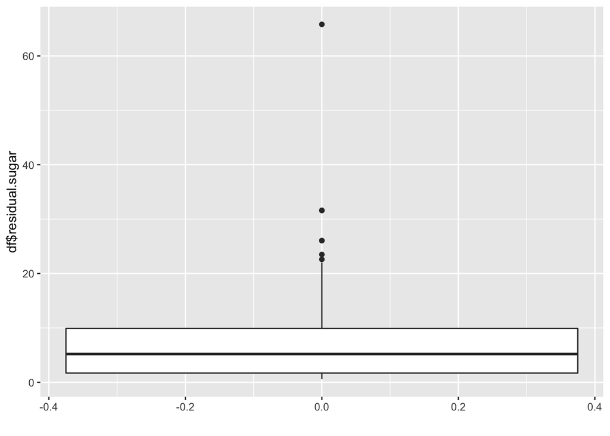

```r
qplot(y = df$residual.sugar, geom='boxplot')
```

```r
library(dplyr)
df = df %>%
  filter(residual.sugar < 65.80)

summary(df$residual.sugar)
```

```
##    Min. 1st Qu.  Median    Mean 3rd Qu.    Max.
##   0.600   1.700   5.200   6.379   9.900  31.600
```

# Bivariate Plots Section

```
##                residual.sugar          pH    alcohol     quality
## residual.sugar     1.00000000 -0.20019028 -0.4594624 -0.09930808
## pH                -0.20019028  1.00000000  0.1212028  0.09940794
## alcohol           -0.45946236  0.12120276  1.0000000  0.43558973
## quality           -0.09930808  0.09940794  0.4355897  1.00000000
## density            0.83396910 -0.10004572 -0.8018871 -0.31489732
##                   density
## residual.sugar  0.8339691
## pH             -0.1000457
## alcohol        -0.8018871
## quality        -0.3148973
## density         1.0000000
```

# Bivariate Analysis

### Talk about some of the relationships you observed in this part of the investigation. How did the feature(s) of interest vary with other features in the dataset?

#### residual和alcohol的相关性较强，呈负相关。quality和alcohol正相关性较强。pH与residual.sugar和quality相关性都很弱。

### Did you observe any interesting relationships between the other features (not the main feature(s) of interest)?

#### density与residual.sugar有很强的正相关性，与alcohol有很强的负相关性。

### What was the strongest relationship you found?

#### density与residual.sugar和alcohol

# Multivariate Plots Section

```
##
## (2,5] (5,7] (7,9]
##  1640  3077   180
```

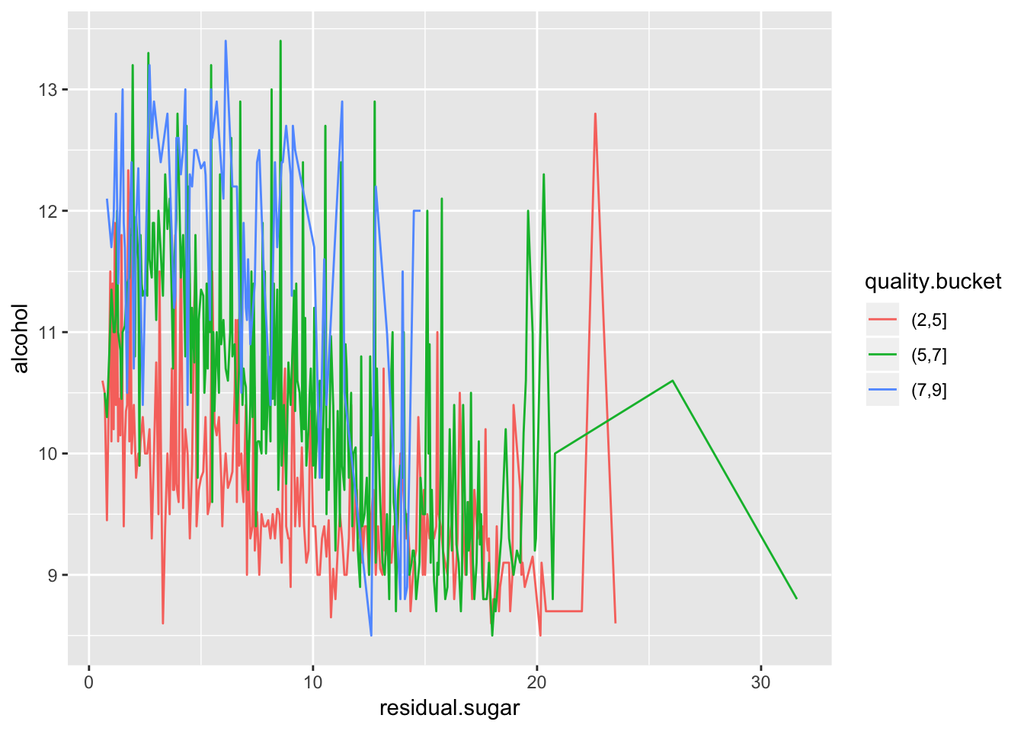

```r
ggplot(aes(x = residual.sugar, y = alcohol),
              data = df_sel) +
  geom_line(aes(color = quality.bucket), stat = 'summary', fun.y = median)
```

# Multivariate Analysis

### Talk about some of the relationships you observed in this part of the investigation. Were there features that strengthened each other in terms of looking at your feature(s) of interest?

#### 品质越高的酒，其residual.sugar值相对较低，且alcohol较高。

### Were there any interesting or surprising interactions between features?

### OPTIONAL: Did you create any models with your dataset? Discuss the strengths and limitations of your model.

# Final Plots and Summary

### Plot One

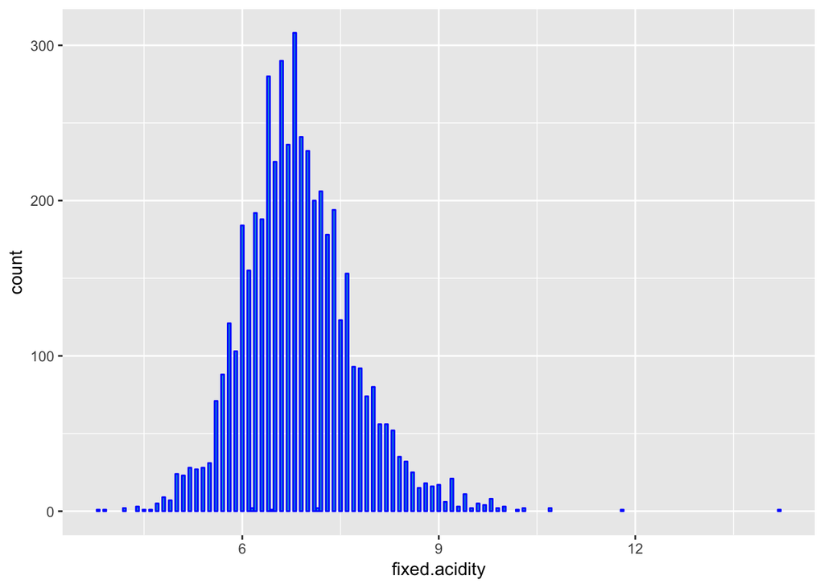

```r
ggplot(data = df, aes(x = fixed.acidity)) +
  geom_bar(color = 'blue', fill = '#099DD9')
```

非挥发性酸的分布呈正太分布，主要集中在5到8之间。

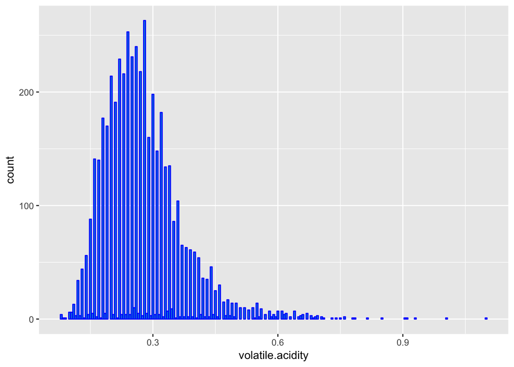

```r
ggplot(data = df, aes(x = volatile.acidity)) +
  geom_bar(color = 'blue', fill = '#099DD9')
```

挥发性酸的分布有点呈右偏，大部分值分布在0.6以下。

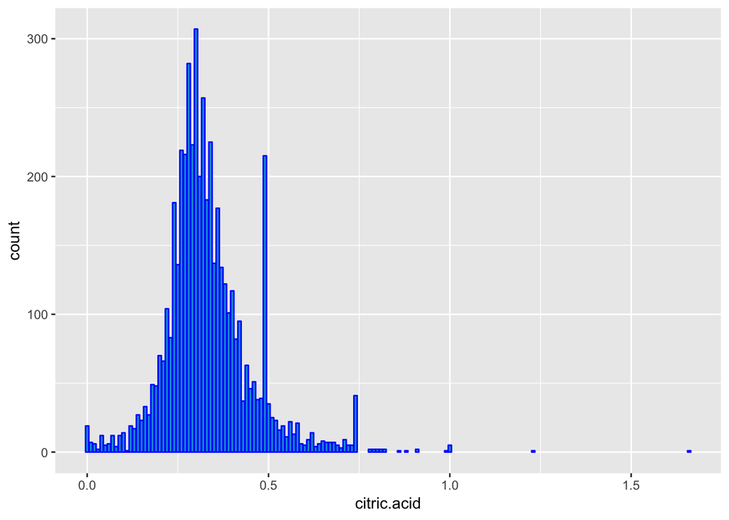

```r
ggplot(data = df, aes(x = citric.acid)) +
  geom_bar(color = 'blue', fill = '#099DD9')
```

柠檬酸成份值主要集中在0.0到0.5之间。

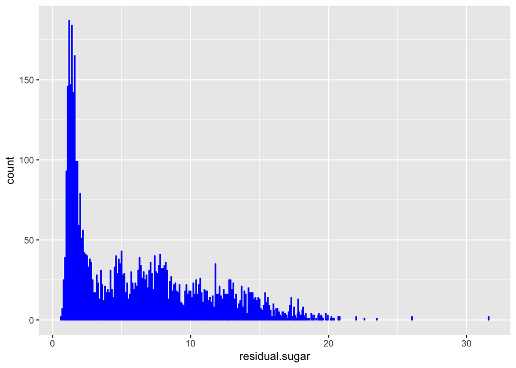

```r
ggplot(data = df, aes(x = residual.sugar)) +
  geom_bar(color = 'blue', fill = '#099DD9')
```

剩余糖份大部分都在20以下，0到3左右居多。

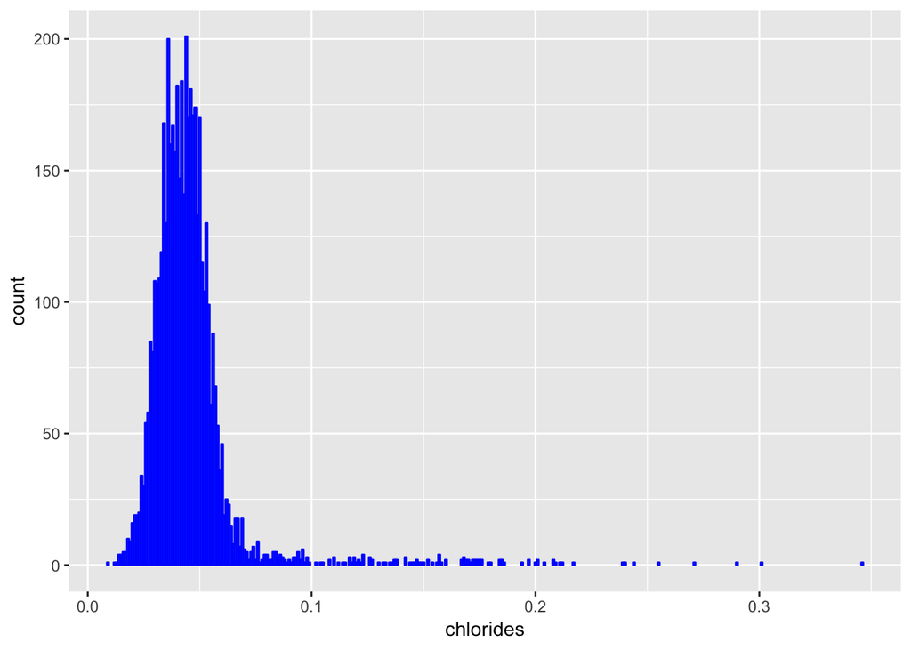

```r
ggplot(data = df, aes(x = chlorides)) +
  geom_bar(color = 'blue', fill = '#099DD9')
```

氯化物的含量大部分在0.0到0.1之间。

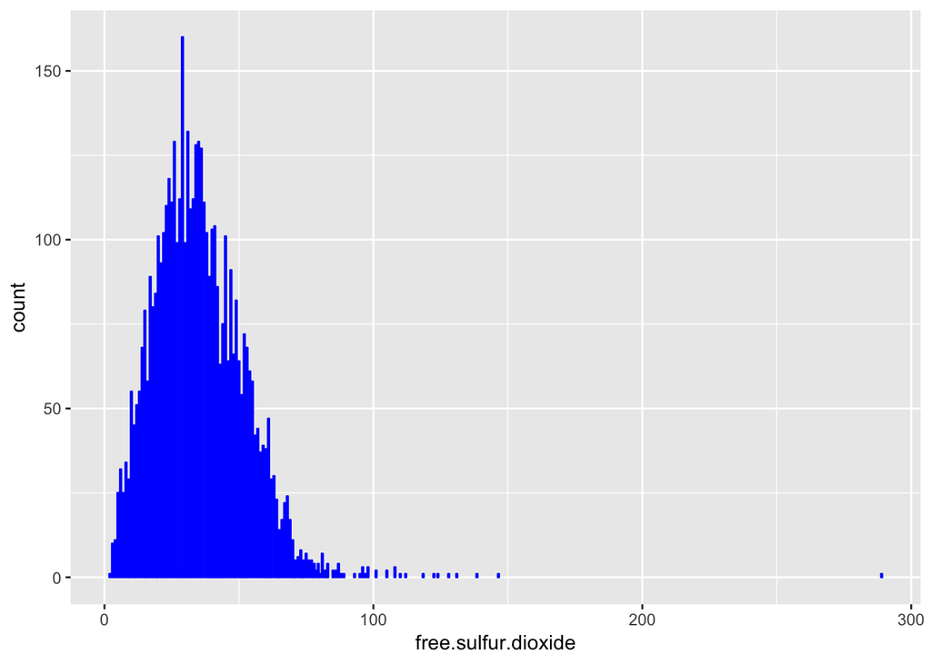

```r
ggplot(data = df, aes(x = free.sulfur.dioxide)) +
  geom_bar(color = 'blue', fill = '#099DD9')
```

游离二氧化硫含量大部分都在100以下，有极少量分布在280左右，可能是异常值。

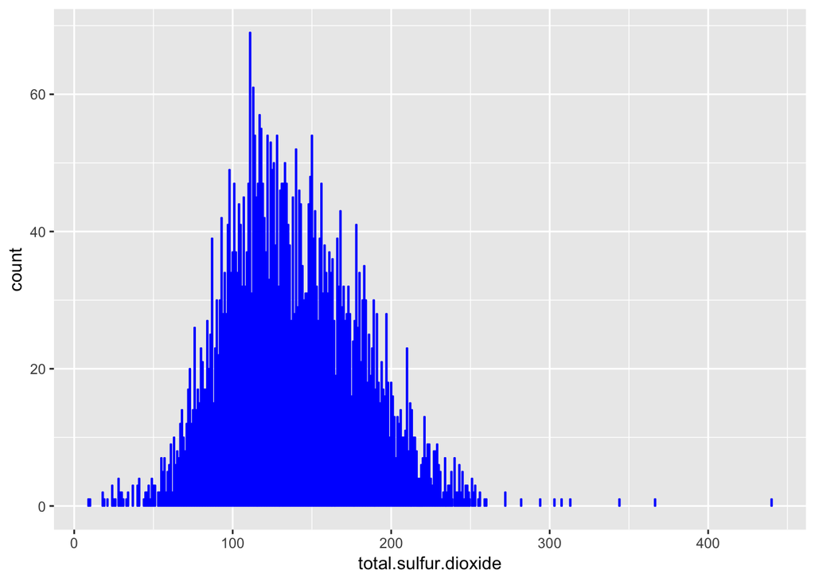

```r
ggplot(data = df, aes(x = total.sulfur.dioxide)) +
  geom_bar(color = 'blue', fill = '#099DD9')
```

总二氧化硫含量基本上呈正太分布。

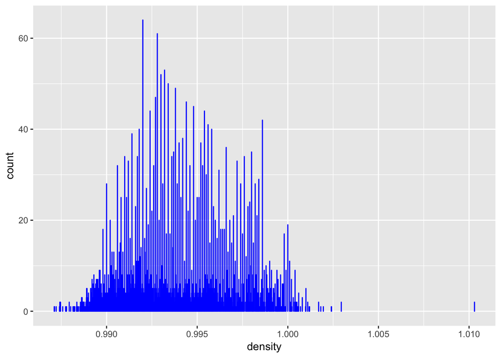

```r
ggplot(data = df, aes(x = density)) +
  geom_bar(color = 'blue', fill = '#099DD9')
```

密度基本上在1以下。

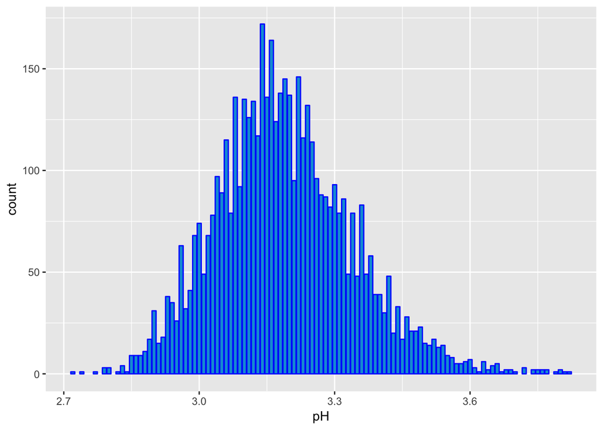

```r
ggplot(data = df, aes(x = pH)) +
  geom_bar(color = 'blue', fill = '#099DD9')
```

pH都主要集中在2.7到3.9之间。

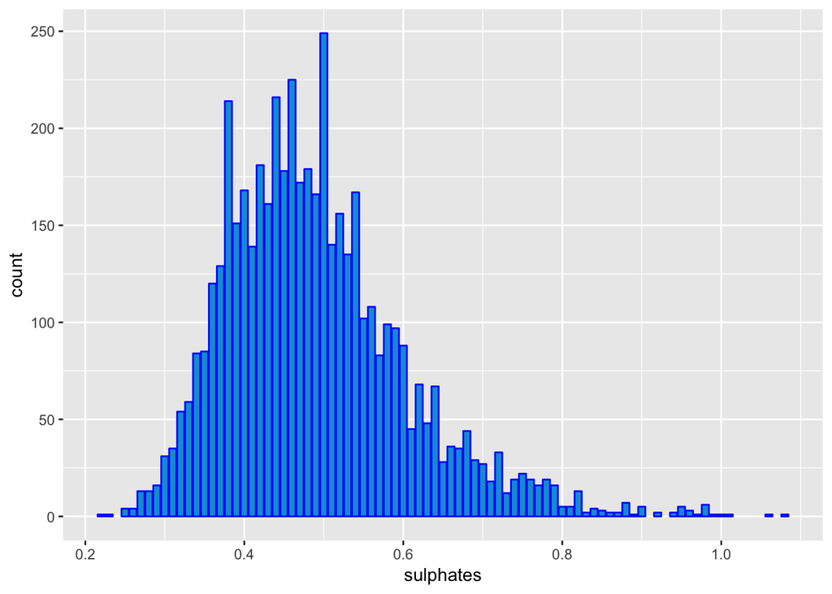

```r
ggplot(data = df, aes(x = sulphates)) +
  geom_bar(color = 'blue', fill = '#099DD9')
```

硫酸盐主要在0.3到0.7之间。

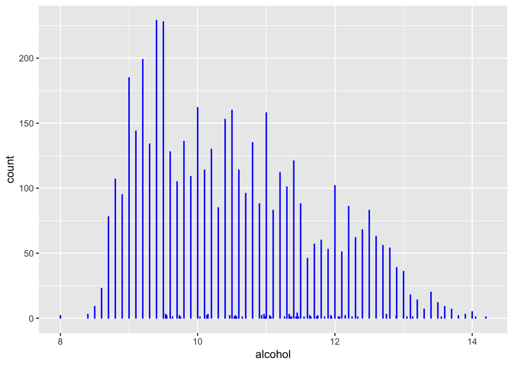

```r
ggplot(data = df, aes(x = alcohol)) +
  geom_bar(color = 'blue', fill = '#099DD9')
```

酒精度数在8到15度之间。

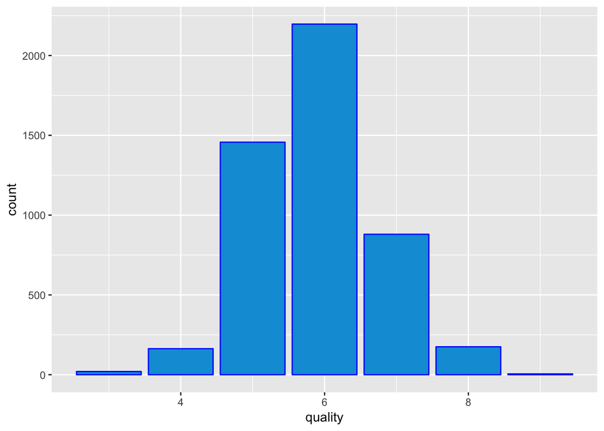

```r
ggplot(data = df, aes(x = quality)) +
  geom_bar(color = 'blue', fill = '#099DD9')
```

质量评分基本在4到8分。

### Plot Two

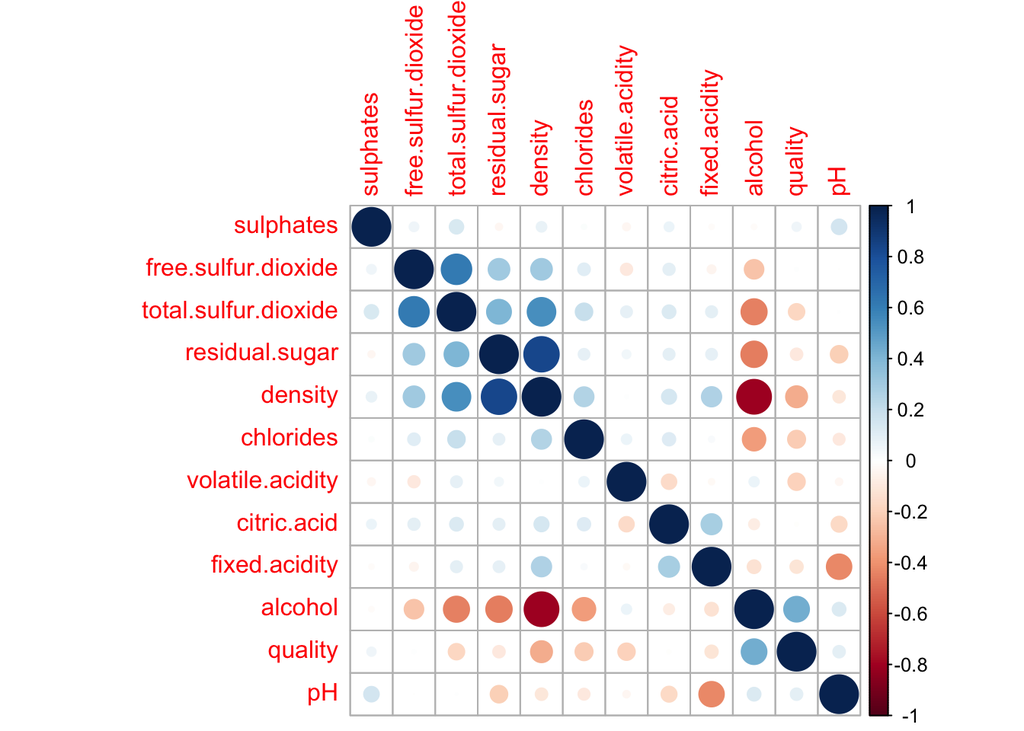

### Description Two

#### free.sulfur.dioxide 与 total.sulfur.dioxide 正相关性较强，

#### residual.sugar 与 desity 正相关性较强

#### total.sulfur.dioxide 与 dnsity 正相关性较强

#### alcohol 与 density,total.surful.dioxide,residual.sugar,chlorides 负相关性较强

#### pH 与 fixed.acidity 负相关性较强

#### 对于酒的品质来说，与alcohol呈正相关，与density呈负相关

### Plot Three

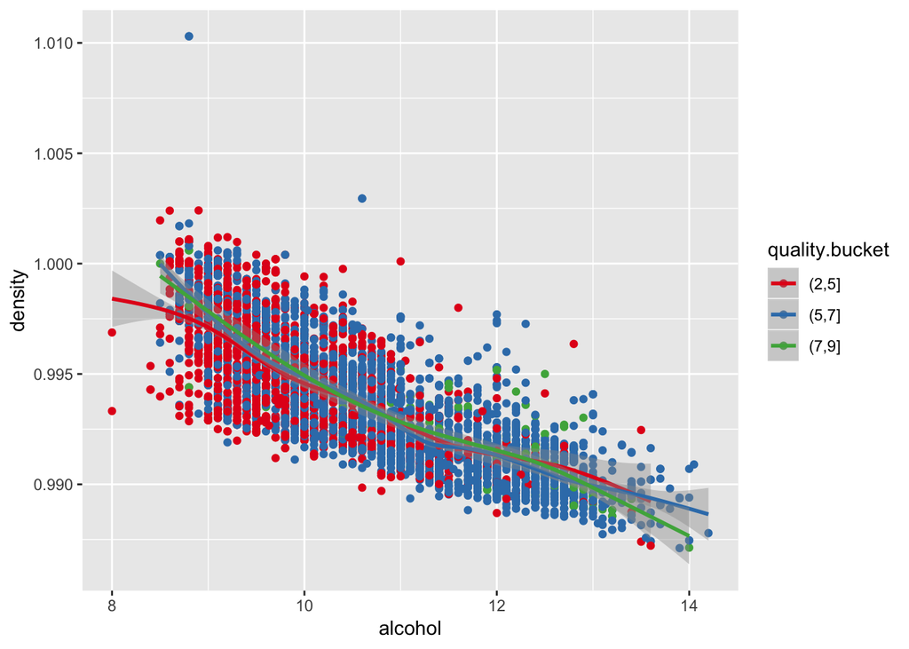

### Description Three

# Reflection

数据评估主要从以下几个点考虑： a. 数据完整性: 主要评估数据缺失程度，分为数据信息缺失和数据字段缺失。 b. 数据准确性: 主要是评估数据是否包含异常值，可能由于人员手工录入错误等，比如身份证号码是否满足校验规则等。 c. 数据有效性: 主要是评估数据的取值的类型、值域、格式是否正确，比如数据是有关驾驶人员的信息，那么年龄就必须满足（小型汽车 18-70岁）范围内。 d. 数据实效性: 主要是指信息仅在一定时间范围内对决策有所作用，如果时间太久，这个信息就没有价值。 e. 数据一致性: 主要是当多表关联时，主表与子表关联字段是否一致。

单一变量分析主要是通过基本的统计分析，如均值、中位数、众数、方差、标准差，通过分为数来分析异常值等，通过直方图可以很直观的看到每个变量的分布情况，通过箱线图可以直观的发现异常值。 两个变量分析主要通过协方差计算，结合热力图等分析变量间的相关性。 通过数据分析了解成份间的相关性可以帮助我们在生产白酒过程中，对原材料的成份配比有很大的帮助。